# Stephanie’s Housing Request

**Week 2 Analysis**

```r
library(mosaic)
library(tidyverse)
library(pander)
library(knitr)
library(DT) # If you get an error stating:
            # Error in library(DT): there is no package called 'DT'
            # You will need to run: install.packages("DT")
            # in your Console, then try "Knit HTML" again.
Rent <- read_csv("../Data/Rent.csv")
```

## Background

“Hi. My name is Stephanie. I would like to learn about what housing options I have for living at BYU-Idaho next semester. It will be my first semester there, so I would like to find something that is close to campus and around $300 a month in rent. I’m not too picky on roommates, but I would like somewhere that has a lot of people around so I can get to know as many people as possible. Thanks in advance!”

## Response

Dear Stephanie,

Below are my top 4 reccomendations for where to live. Based on cost, distance to campus, and number of residents, I have narrowed down the options to the following apartments.

```r
# Code to get you started, be sure to use a subset of Rent instead of Rent in this code though.
# datatable(Rent, options=list(lengthMenu = c(3,10,30)), extensions="Responsive")

women_housing <- Rent %>%
  filter(Gender == "F")

women_housing2 <- women_housing %>%
  mutate(
    AvgFloorPlanCostMonthly = AvgFloorPlanCost / 4)

women_housing_main <- women_housing2 %>%
  filter(AvgFloorPlanCostMonthly <= 300)

# View(women_housing_main)

women_housing3 <- women_housing_main %>%
  filter(Residents > (median(women_housing_main$Residents)) &
    CrowFlyMetersToMC <  median(women_housing_main$CrowFlyMetersToMC))

# View(women_housing3)
```

```r
women_housing_table <- women_housing3 %>%
  select(Name, AvgFloorPlanCostMonthly, Residents, CrowFlyMetersToMC)
women_housing_table %>%
  kable() #Kable is a way to turn the table into looking cleaner. This way it's more professional to read.
```

| Name | AvgFloorPlanCostMonthly | Residents | CrowFlyMetersToMC |
| --- | --- | --- | --- |
| DAVENPORT APARTMENTS | 223.75 | 71 | 470.7798 |
| RIVIERA APARTMENTS | 243.75 | 82 | 248.4575 |
| ROYAL CREST | 248.75 | 342 | 427.4957 |
| SOMERSET APARTMENTS - WOMEN | 300.00 | 180 | 467.4360 |

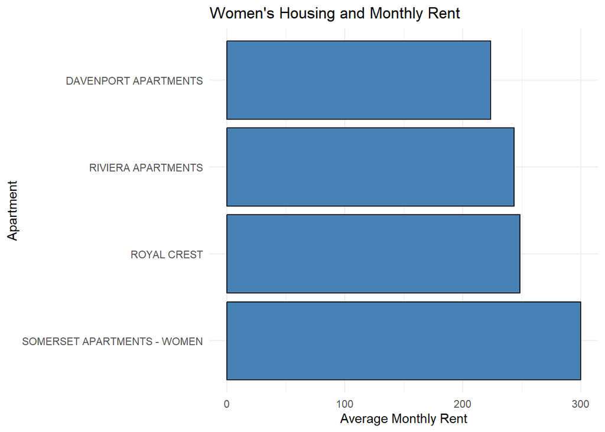

```r
ggplot(women_housing3, aes(x = reorder(Name, -AvgFloorPlanCostMonthly), y = AvgFloorPlanCostMonthly)) +
  geom_col(fill = "steelblue", color = "black") +
  labs(title = "Women's Housing and Monthly Rent",
       x = "Apartment",
       y = "Average Monthly Rent") +
  theme_minimal() +
  coord_flip()
```

-Residents were narrowed down from the given choices to those that had average and above average resident amounts.

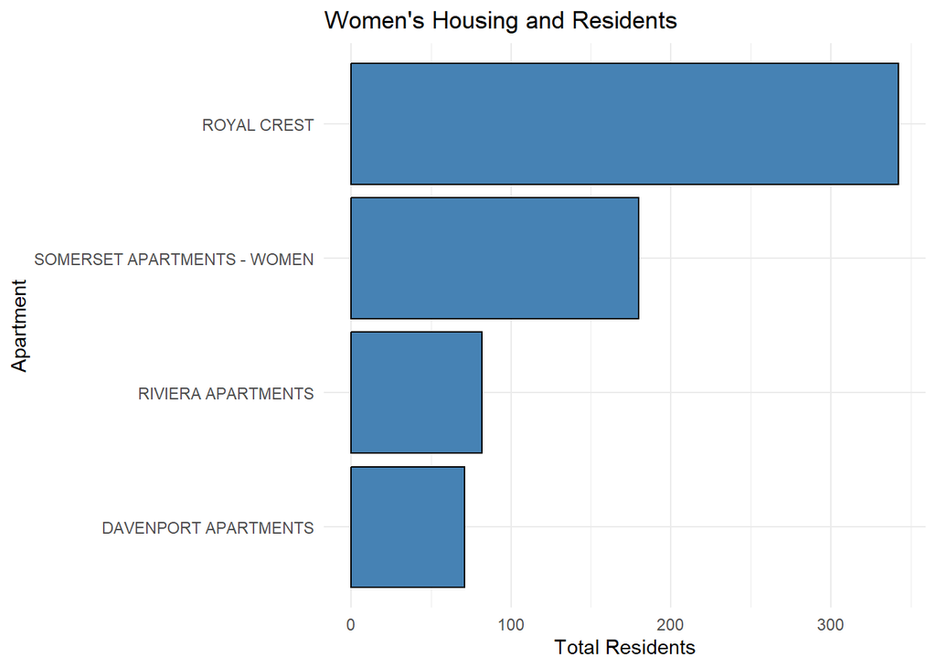

```r
ggplot(women_housing3, aes(x = reorder(Name, Residents), y = Residents)) +
  geom_col(fill = "steelblue", color = "black") +
  labs(title = "Women's Housing and Residents",
       y = "Total Residents",
       x = "Apartment") +
  theme_minimal() +
  coord_flip()
```

-The green colored dots are the 4 I suggest you look into. The red dots are the ones that are sufficient. The blue dots are the ones that are not as cheap as you would like or farther away then desired. The size of the dots represent the number of residents in the apartment. The table below that is a few other suggestions if for some reason the favorites don’t work out for you.

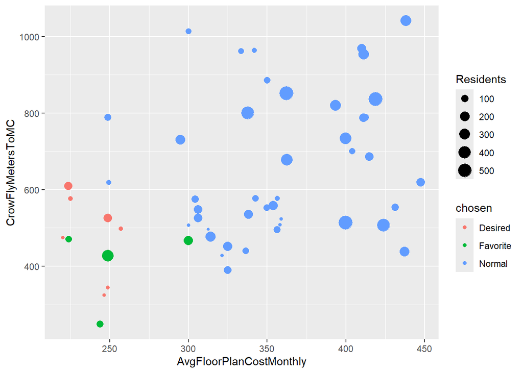

```r
# ggplot(women_housing3, aes(x = reorder(Name, -CrowFlyMetersToMC), y = CrowFlyMetersToMC)) +
#   geom_col(fill = "steelblue", color = "black") +
#   labs(title = "Women's Housing and Distance to MC",
#        x = "Apartment",
#        y = "Distance to MC") +
#   theme_minimal() +
#   coord_flip()

womenhousing4 <- women_housing2 %>%
  filter(Gender == "F")


womenhousing4$chosen <- ifelse(womenhousing4$Name %in% women_housing3$Name, "Favorite",ifelse(womenhousing4$AvgFloorPlanCostMonthly < 300 & womenhousing4$CrowFlyMetersToMC < 618,
                                      "Desired",
                                      "Normal"))


meanhousing <- womenhousing4 %>%
  summarize(mean_cost = mean(AvgFloorPlanCostMonthly), mean_distance = mean(CrowFlyMetersToMC))

belowmean <- womenhousing4 %>%
  filter(womenhousing4$chosen == "Desired")

belowmean2 <- select(belowmean, c(Name, AvgFloorPlanCostMonthly, CrowFlyMetersToMC, Residents))

# belowmean2 <- round(belowmean2$AvgFloorPlanCostMonthly, 2)
# belowmean2 <- round(belowmean2$CrowFlyMetersToMC, 2)



# meanhousing %>% kable()

ggplot(womenhousing4, aes(x =AvgFloorPlanCostMonthly, y= CrowFlyMetersToMC, color = chosen, size = Residents)) + geom_point()
```

```r
belowmean2 %>% kable()
```

| Name | AvgFloorPlanCostMonthly | CrowFlyMetersToMC | Residents |
| --- | --- | --- | --- |
| BAYSIDE MANOR | 246.2500 | 325.1113 | 8 |
| BROOKLYN APARTMENTS | 248.7500 | 525.4233 | 144 |
| BUENA VISTA | 225.0000 | 576.1872 | 21 |
| CRESTWOOD COTTAGE | 248.7500 | 344.0627 | 10 |
| HILL’S COLLEGE AVE APTS | 220.0000 | 475.2382 | 8 |
| PINES, THE - WOMEN | 223.5825 | 610.1699 | 126 |
| SUNSET HALL | 256.8750 | 498.9087 | 14 |

```r
# Creating ranked columns
women_housing3$Rank_AvgFloorPlanCostMonthly <- rank(women_housing3$AvgFloorPlanCostMonthly, ties.method = "min")
women_housing3$Rank_Residents <- rank(women_housing3$Residents, ties.method = "min")
women_housing3$Rank_Distance_MC <- rank(women_housing3$CrowFlyMetersToMC, ties.method = "min")

women_housing3$Average_Row <- rowMeans(women_housing3[, c("Rank_AvgFloorPlanCostMonthly", "Rank_Residents", "Rank_Distance_MC")], na.rm = TRUE)


women_housing3$Average_Row <- round(women_housing3$Average_Row, 2)
```

## Conclusion

```r
women_ranking_table <- women_housing3 %>%
  select(Name, Rank_AvgFloorPlanCostMonthly, Rank_Residents, Rank_Distance_MC, Average_Row)
women_ranking_table %>%
  kable()
```

| Name | Rank_AvgFloorPlanCostMonthly | Rank_Residents | Rank_Distance_MC | Average_Row |
| --- | --- | --- | --- | --- |
| DAVENPORT APARTMENTS | 1 | 1 | 4 | 2.00 |
| RIVIERA APARTMENTS | 2 | 2 | 1 | 1.67 |
| ROYAL CREST | 3 | 4 | 2 | 3.00 |
| SOMERSET APARTMENTS - WOMEN | 4 | 3 | 3 | 3.33 |

```r
# ggplot(women_housing3, aes(x = reorder(Name, -Average_Row), y = Average_Row)) + #The "-" means to make the order descending. To flip it.
#   geom_col(fill = "steelblue", color = "black") +
#   labs(title = "Average Ranking of Apartments",
#        x = "Apartment",
#        y = "Average Rank") +
#   theme_minimal() +
#   coord_flip()


# View(women_housing3)
```